# repores

Asad Ali Shah

5/8/2020

# Reproducible Research Assignment

Given below are the steps taken to conduct the data analysis. Following package would be required so lets make them available from the beginning.

```r
library(dplyr)
```

```r
library(ggplot2)
library(mice)
library(lubridate)
library(gridExtra)
```

## Downloading and reading the data

```r
loc <- "https://d396qusza40orc.cloudfront.net/repdata%2Fdata%2Factivity.zip"
download.file(loc, destfile = "repores")
unzip("repores")
df <- read.csv("activity.csv")
head(df)
```

```
##   steps       date interval
## 1    NA 2012-10-01        0
## 2    NA 2012-10-01        5
## 3    NA 2012-10-01       10
## 4    NA 2012-10-01       15
## 5    NA 2012-10-01       20
## 6    NA 2012-10-01       25
```

## Histogram of steps by day

Tranforming the date to be make it ready for the plot.

```r
steps.by.day <- df %>%
        group_by(date) %>%
        summarize(steps = sum(steps), na.rm = T)
```

Now, the condensed dataframe **steps.by.day** is ready to be used for plot creations.

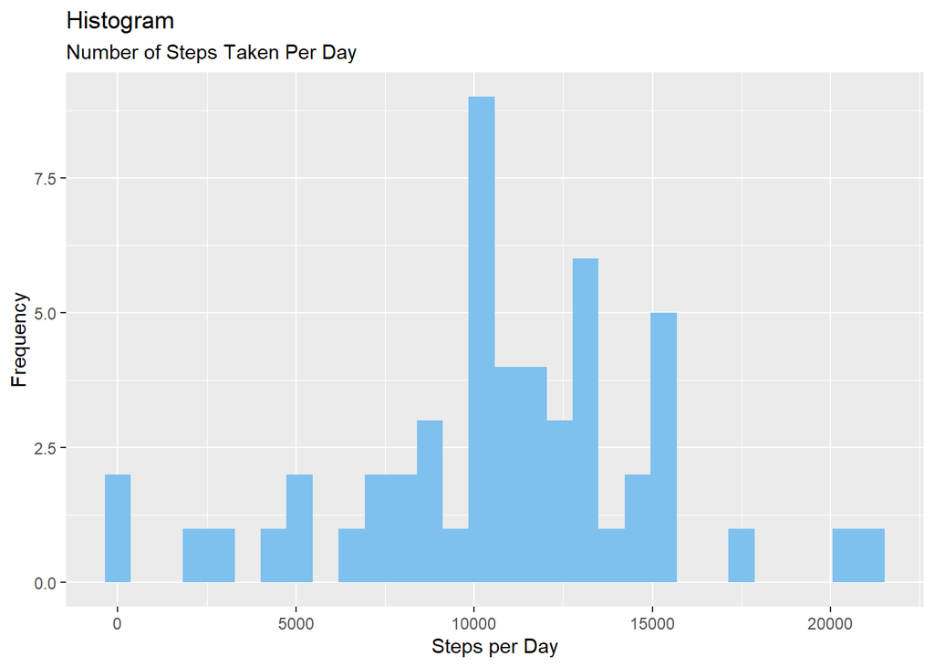

```r
ggplot(steps.by.day, aes(steps)) +
    geom_histogram(fill = "skyblue2") +
    ggtitle("Histogram", "Number of Steps Taken Per Day") +
    labs(x = "Steps per Day", y = "Frequency")
```

## Mean and median of steps per days

```r
central <- df %>%
        group_by(date) %>%
        summarize(Total = sum(steps),
              Average = mean(steps),
              Median = median(steps))

head(central)
```

```
## # A tibble: 6 x 4
##   date       Total Average Median
##   <fct>      <int>   <dbl>  <dbl>
## 1 2012-10-01    NA  NA         NA
## 2 2012-10-02   126   0.438      0
## 3 2012-10-03 11352  39.4        0
## 4 2012-10-04 12116  42.1        0
## 5 2012-10-05 13294  46.2        0
## 6 2012-10-06 15420  53.5        0
```

## Time series plot of the average number of steps taken

First we create a summarized dataframe **time.series** to ready the data for the timeseries plot.

```r
time.series <- df %>%
        group_by(date) %>%
        summarize(Average = mean(steps),
                  Median = median(steps))

head(time.series)
```

```
## # A tibble: 6 x 3
##   date       Average Median
##   <fct>        <dbl>  <dbl>
## 1 2012-10-01  NA         NA
## 2 2012-10-02   0.438      0
## 3 2012-10-03  39.4        0
## 4 2012-10-04  42.1        0
## 5 2012-10-05  46.2        0
## 6 2012-10-06  53.5        0
```

Using the **time.series** dataframe, here we create the time series plot for the avearge number of steps taken per day. Note that to run this plot, you will need to make **lubradiate** package available which is used for date transformation.

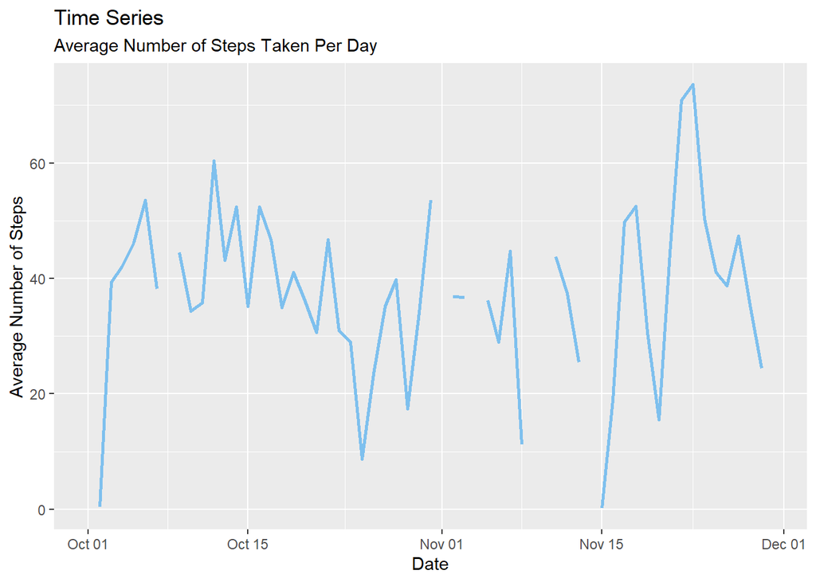

```r
ggplot(time.series, aes(x=ymd(date), y=Average)) +
    geom_line(color = "skyblue2", size = 1, na.rm = T) +
    ggtitle("Time Series", "Average Number of Steps Taken Per Day") +
    labs(x = "Date", y = "Average Number of Steps")
```

Also note the discontinuations or breaks in the line which are caused by the missing data.

Using the same dataframe, here we create the time series plot for the median number of steps take per day which interestly shows that median number of steps in all intervals is zero.

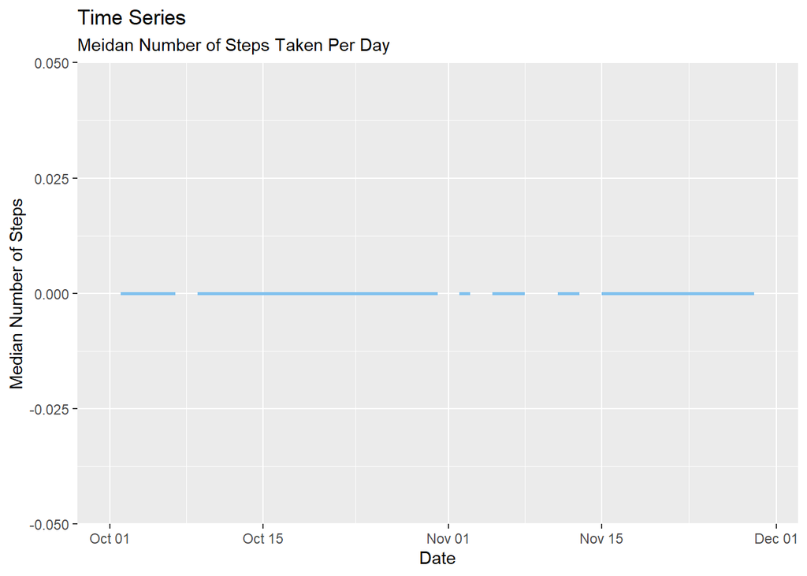

```r
ggplot(time.series, aes(x=ymd(date), y=Median)) +
    geom_line(color = "skyblue2", size = 1, na.rm = T) +
    ggtitle("Time Series", "Meidan Number of Steps Taken Per Day") +
    labs(x = "Date", y = "Median Number of Steps")
```

I always wanted to find a way to combine two ggplot charts objetcs in a single frame. Apparently, this is not possible in **ggplot2** system however there is a package for that. That is **gridExtra**.

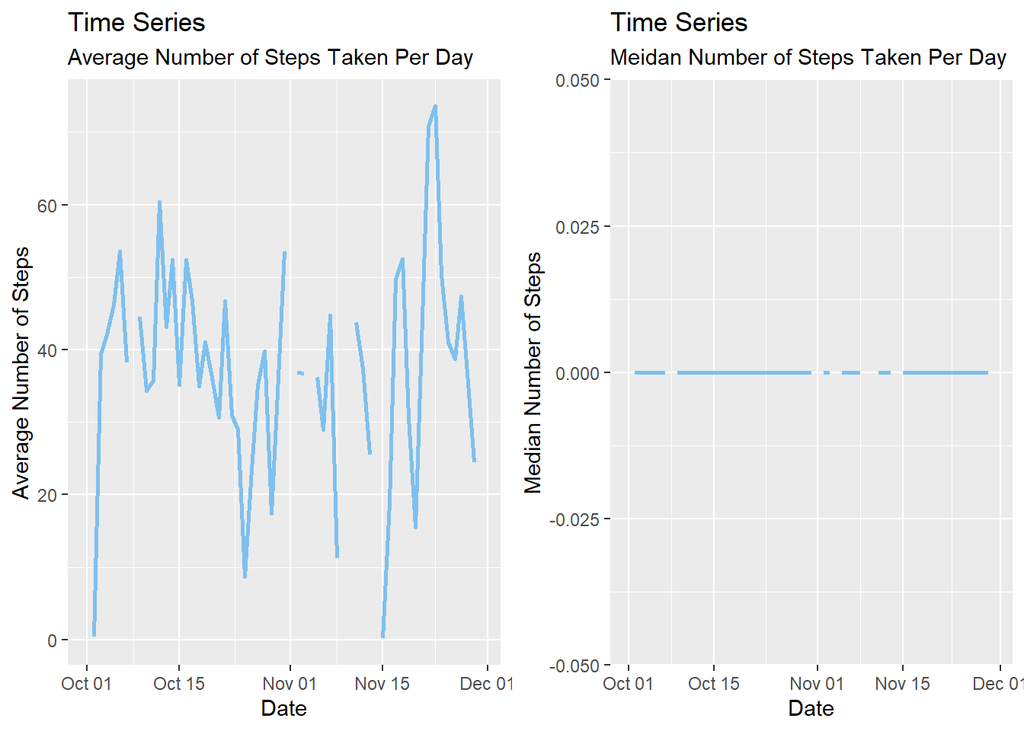

```r
plot1 <- ggplot(time.series, aes(x=ymd(date), y=Average)) +
    geom_line(color = "skyblue2", size = 1, na.rm = T) +
    ggtitle("Time Series", "Average Number of Steps Taken Per Day") +
    labs(x = "Date", y = "Average Number of Steps")

plot2 <- ggplot(time.series, aes(x=ymd(date), y=Median)) +
    geom_line(color = "skyblue2", size = 1, na.rm = T) +
    ggtitle("Time Series", "Meidan Number of Steps Taken Per Day") +
    labs(x = "Date", y = "Median Number of Steps")

grid.arrange(plot1, plot2, ncol = 2)
```

## Maximum steps

First a bit of data transformation.

```r
# max steps by interval
intrvl <- df %>%
        group_by(interval) %>%
        summarize(Average = mean(steps, na.rm = T))
```

We also need to find out which interval has the maximum number of steps.

```r
which.max(intrvl$Average)
```

```
## [1] 104
```

```r
intrvl[104,]
```

```
## # A tibble: 1 x 2
##   interval Average
##      <int>   <dbl>
## 1      835    206.
```

Here goes the plot where we use the above information for annotations purposes.

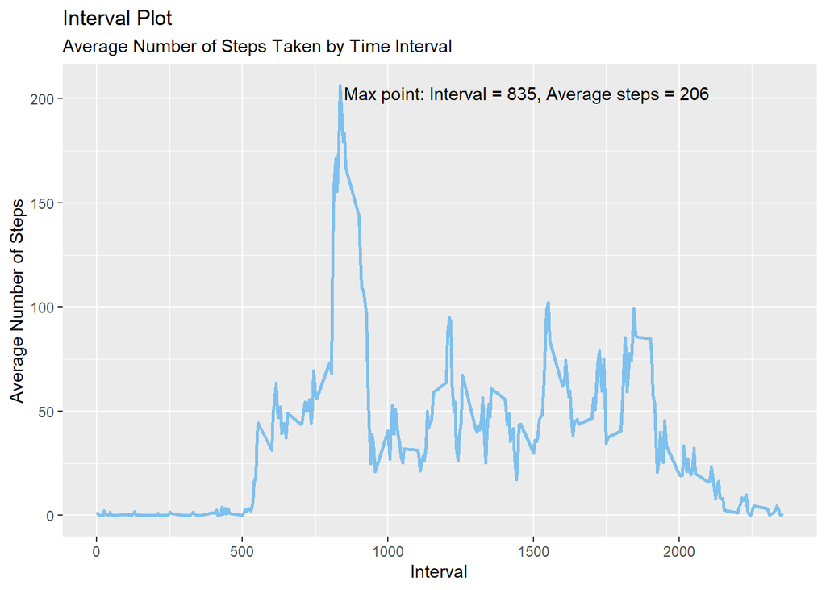

```r
ggplot(intrvl, aes(x=interval, y=Average)) +
    geom_line(color = "skyblue2", size = 1, na.rm = T) +
    ggtitle("Interval Plot", "Average Number of Steps Taken by Time Interval") +
    labs(x = "Interval", y = "Average Number of Steps") +
    annotate("text", x = 835+15, y = 206, vjust = "inward", hjust = "inward",
             label = paste0("Max point: Interval = 835, Average steps = 206"))
```